# Sama Amr Habib - Use Case(Loan Defaulter)

# Correlation Matrix

Filter Out Less Relevant Features consider focusing on a subset of the most relevant ones to get a clearer view.

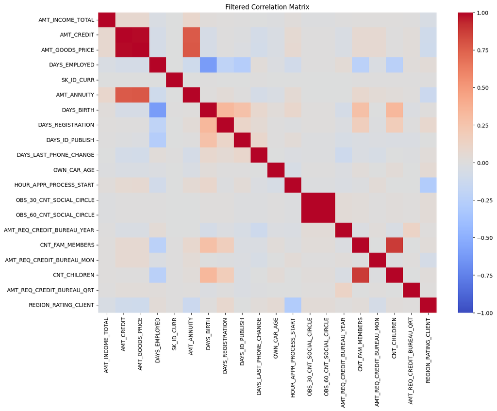

```python
# filter numerical columns based on variance or other criteria
filtered_columns = numeric_data.var().sort_values(ascending=False).index[:20]  # Top 20 features by variance
filtered_data = numeric_data[filtered_columns]

# Compute the correlation matrix for the filtered data
filtered_corr_matrix = filtered_data.corr()

# Plot the heatmap
plt.figure(figsize=(14, 10))
sns.heatmap(filtered_corr_matrix, annot=False, cmap='coolwarm', vmin=-1, vmax=1)
plt.title('Filtered Correlation Matrix')
plt.show()
```

# Feature Scaling

Standardize or normalize your numerical features to ensure they contribute equally to the model.

StandardScaler: is a preprocessing technique used to standardize features by removing the mean and scaling to unit variance. It transforms data such that each feature has a mean of 0 and a standard deviation of 1.

```python
from sklearn.preprocessing import StandardScaler

scaler = StandardScaler()
data[numerical_features] = scaler.fit_transform(data[numerical_features])
```

Standardization is used in this case to scale numerical features so that they have a mean of 0 and a standard deviation of 1, which is beneficial for many machine learning algorithms. It is different from normalization, which scales data to a specific range and is more suited for algorithms that rely on distances or when you need features to lie within a specific range.

# Feature Engineering

Create or modify features to improve model performance.

```python
# Example: Creating interaction features
data['AMT_INCOME_TOTAL_X_AMT_CREDIT'] = data['AMT_INCOME_TOTAL'] * data['AMT_CREDIT']
```

```python
data.head()
```

|  | SK_ID_CURR | TARGET | NAME_CONTRACT_TYPE | CODE_GENDER | FLAG_OWN_CAR | FLAG_OWN_REALTY | CNT_CHILDREN | AMT_INCOME_TOTAL | AMT_CREDIT | AMT_ANNUITY | ... | CNT_PAYMENT | NAME_YIELD_GROUP | PRODUCT_COMBINATION | DAYS_FIRST_DRAWING | DAYS_FIRST_DUE | DAYS_LAST_DUE_1ST_VERSION | DAYS_LAST_DUE | DAYS_TERMINATION | NFLAG_INSURED_ON_APPROVAL | AMT_INCOME_TOTAL_X_AMT_CREDIT |
| --- | --- | --- | --- | --- | --- | --- | --- | --- | --- | --- | --- | --- | --- | --- | --- | --- | --- | --- | --- | --- | --- |
| 0 | -1.237247 | 6.307039 | Cash loans | M | N | Y | -0.288433 | 0.187766 | 0.237728 | 0.432350 | ... | -0.182591 | XNA | POS household with interest | 0.160412 | -0.132104 | -0.198249 | -0.31426 | -0.324864 | -0.403214 | 0.044637 |
| 1 | -1.237238 | -0.158553 | Cash loans | F | N | N | -0.288433 | 0.438553 | 2.515699 | 1.179604 | ... | -0.182591 | XNA | POS household with interest | 0.160412 | -0.132104 | -0.198249 | -0.31426 | -0.324864 | -0.403214 | 1.103267 |
| 2 | -1.237229 | -0.158553 | Revolving loans | M | Y | Y | -0.288433 | -0.313807 | -0.459856 | -0.787289 | ... | -0.182591 | XNA | POS household with interest | 0.160412 | -0.132104 | -0.198249 | -0.31426 | -0.324864 | -0.403214 | 0.144306 |
| 3 | -1.237211 | -0.158553 | Cash loans | F | N | Y | -0.288433 | -0.063021 | -0.003488 | 0.771122 | ... | -0.182591 | XNA | POS household with interest | 0.160412 | -0.132104 | -0.198249 | -0.31426 | -0.324864 | -0.403214 | 0.000220 |
| 4 | -1.237202 | -0.158553 | Cash loans | M | N | Y | -0.288433 | -0.113178 | 0.511018 | 0.239727 | ... | -0.182591 | XNA | POS household with interest | 0.160412 | -0.132104 | -0.198249 | -0.31426 | -0.324864 | -0.403214 | -0.057836 |

5 rows × 153 columns

```python
data.info()
```

```
<class 'pandas.core.frame.DataFrame'>
RangeIndex: 196839 entries, 0 to 196838
Columns: 153 entries, SK_ID_CURR to AMT_INCOME_TOTAL_X_AMT_CREDIT
dtypes: float64(123), object(30)
memory usage: 229.8+ MB
```

# Encode Categorical Variables

Convert categorical variables into numerical form using techniques like one-hot encoding or label encoding.

```python
# Example: One-hot encoding categorical features
data = pd.get_dummies(data, drop_first=True)
```

```python
# Check data types after one-hot encoding
print(data.dtypes.to_string())
```

```
SK_ID_CURR                                                     float64
TARGET                                                         float64
CNT_CHILDREN                                                   float64
AMT_INCOME_TOTAL                                               float64
AMT_CREDIT                                                     float64
AMT_ANNUITY                                                    float64
AMT_GOODS_PRICE                                                float64
REGION_POPULATION_RELATIVE                                     float64
DAYS_BIRTH                                                     float64
DAYS_EMPLOYED                                                  float64
DAYS_REGISTRATION                                              float64
DAYS_ID_PUBLISH                                                float64
OWN_CAR_AGE                                                    float64
FLAG_MOBIL                                                     float64
FLAG_EMP_PHONE                                                 float64
FLAG_WORK_PHONE                                                float64
FLAG_CONT_MOBILE                                               float64
FLAG_PHONE                                                     float64
FLAG_EMAIL                                                     float64
CNT_FAM_MEMBERS                                                float64
REGION_RATING_CLIENT                                           float64
REGION_RATING_CLIENT_W_CITY                                    float64
HOUR_APPR_PROCESS_START                                        float64
REG_REGION_NOT_LIVE_REGION                                     float64
REG_REGION_NOT_WORK_REGION                                     float64
LIVE_REGION_NOT_WORK_REGION                                    float64
REG_CITY_NOT_LIVE_CITY                                         float64
REG_CITY_NOT_WORK_CITY                                         float64
LIVE_CITY_NOT_WORK_CITY                                        float64
EXT_SOURCE_1                                                   float64
EXT_SOURCE_2                                                   float64
EXT_SOURCE_3                                                   float64
APARTMENTS_AVG                                                 float64
BASEMENTAREA_AVG                                               float64
YEARS_BEGINEXPLUATATION_AVG                                    float64
YEARS_BUILD_AVG                                                float64
COMMONAREA_AVG                                                 float64
ELEVATORS_AVG                                                  float64
ENTRANCES_AVG                                                  float64
FLOORSMAX_AVG                                                  float64
```

[output cut: 307 more lines]

```
PRODUCT_COMBINATION_Cash                                          bool
PRODUCT_COMBINATION_Cash Street: high                             bool
PRODUCT_COMBINATION_Cash Street: low                              bool
PRODUCT_COMBINATION_Cash Street: middle                           bool
PRODUCT_COMBINATION_Cash X-Sell: high                             bool
PRODUCT_COMBINATION_Cash X-Sell: low                              bool
PRODUCT_COMBINATION_Cash X-Sell: middle                           bool
PRODUCT_COMBINATION_POS household with interest                   bool
PRODUCT_COMBINATION_POS household without interest                bool
PRODUCT_COMBINATION_POS industry with interest                    bool
PRODUCT_COMBINATION_POS industry without interest                 bool
PRODUCT_COMBINATION_POS mobile with interest                      bool
PRODUCT_COMBINATION_POS mobile without interest                   bool
PRODUCT_COMBINATION_POS other with interest                       bool
PRODUCT_COMBINATION_POS others without interest                   bool
```

# Train-Test Split

Divide your data into training and test sets to evaluate your model's performance.

```python
from sklearn.model_selection import train_test_split

# Assuming 'data' is your DataFrame and 'TARGET' is my target variable
# Separate features and target variable
X = data.drop(columns=['TARGET'])
y = data['TARGET']

# Perform the train-test split
X_train, X_test, y_train, y_test = train_test_split(X, y, test_size=0.2, random_state=42)

# Print shapes of the resulting datasets
print("Training set shape:", X_train.shape)
print("Test set shape:", X_test.shape)
```

```
Training set shape: (157471, 361)
Test set shape: (39368, 361)
```

```python
# Convert continuous target to binary using a threshold
threshold = 0.5
y_train_binary = (y_train > threshold).astype(int)
y_test_binary = (y_test > threshold).astype(int)
```

```python
# import matplotlib.pyplot as plt

# # Clear figures
# plt.close('all')
```

# Model Training

Train a machine learning model on your data.

# LogisticRegression model 1

No Handling of Imbalance

```python
from sklearn.preprocessing import StandardScaler

# Feature scaling
scaler = StandardScaler()
X_train_scaled = scaler.fit_transform(X_train)
X_test_scaled = scaler.transform(X_test)

# Initialize and train the model
model = LogisticRegression(max_iter=1000)
model.fit(X_train_scaled, y_train_binary)

# Make predictions
y_pred = model.predict(X_test_scaled)

# Evaluate the model
accuracy = accuracy_score(y_test_binary, y_pred)
conf_matrix = confusion_matrix(y_test_binary, y_pred)
class_report = classification_report(y_test_binary, y_pred)

print("Accuracy:", accuracy)
print("Confusion Matrix:\n", conf_matrix)
print("Classification Report:\n", class_report)
```

[output not shown]

This model is trained on imbalanced data. It achieves high accuracy by mostly predicting the majority class (non-default). The precision and recall for the minority class (default) are low because the model rarely identifies default cases correctly.

# LogisticRegression model 2

```python
from sklearn.preprocessing import StandardScaler
from sklearn.linear_model import LogisticRegression
from sklearn.metrics import accuracy_score, classification_report, confusion_matrix, roc_auc_score

# Feature scaling
scaler = StandardScaler()
X_train_scaled = scaler.fit_transform(X_train)
X_test_scaled = scaler.transform(X_test)

# Initialize and train the model with increased iterations and balanced class weights
model = LogisticRegression(max_iter=2000, class_weight='balanced')
model.fit(X_train_scaled, y_train_binary)

# Make predictions
y_pred = model.predict(X_test_scaled)

# Evaluate the model
accuracy = accuracy_score(y_test_binary, y_pred)
conf_matrix = confusion_matrix(y_test_binary, y_pred)
class_report = classification_report(y_test_binary, y_pred)
roc_auc = roc_auc_score(y_test_binary, model.predict_proba(X_test_scaled)[:, 1])

print("Accuracy:", accuracy)
print("Confusion Matrix:\n", conf_matrix)
print("Classification Report:\n", class_report)
print("ROC AUC Score:", roc_auc)
```

[output not shown]

# Differences:

**Interpretation and Suggestions:**

1. First Model: The very high accuracy is misleading due to class imbalance. The model performs well on the majority class but poorly on the minority class. This can be problematic in scenarios where the minority class is of high interest.
2. Second Model: The balance between precision and recall for the minority class is better, but the model's overall accuracy is lower. The ROC AUC score suggests that the model can effectively distinguish between classes, even though it struggles with precision for the minority class.

# Decision Tree model

```python
from sklearn.model_selection import train_test_split
from sklearn.tree import DecisionTreeClassifier
from sklearn.metrics import classification_report, confusion_matrix, accuracy_score
```

```python
print(y.unique())
```

```
[ 5.85814653 -0.17070246]
```

Binarize Target Variable

```python
# Assuming y is continuous and you want to convert it into binary (0 or 1)
threshold = 0.5
y_binary = (y > threshold).astype(int)
```

```python
print(y_binary.dtype)  # Should be int
```

```
int64
```

```python
# Use the binarized target variable
X_train, X_test, y_train, y_test = train_test_split(X, y_binary, test_size=0.3, random_state=42)

# Initialize the Decision Tree Classifier
dt_model = DecisionTreeClassifier(random_state=42)

# Train the model
dt_model.fit(X_train, y_train)

# Make predictions
y_pred = dt_model.predict(X_test)

# Evaluate the model
accuracy = accuracy_score(y_test, y_pred)
conf_matrix = confusion_matrix(y_test, y_pred)
class_report = classification_report(y_test, y_pred)

print("Accuracy:", accuracy)
print("Confusion Matrix:\n", conf_matrix)
print("Classification Report:\n", class_report)
```

```
Accuracy: 0.948625
Confusion Matrix:
 [[7553  229]
 [ 182   36]]
Classification Report:
               precision    recall  f1-score   support

           0       0.98      0.97      0.97      7782
           1       0.14      0.17      0.15       218

    accuracy                           0.95      8000
   macro avg       0.56      0.57      0.56      8000
weighted avg       0.95      0.95      0.95      8000
```

# Random Forest model

```python
from sklearn.ensemble import RandomForestClassifier
from sklearn.metrics import accuracy_score, confusion_matrix, classification_report

# Initialize and train the Random Forest model
rf_model = RandomForestClassifier(random_state=42)
rf_model.fit(X_train, y_train)

# Make predictions
y_pred = rf_model.predict(X_test)

# Evaluate the model
accuracy = accuracy_score(y_test, y_pred)
conf_matrix = confusion_matrix(y_test, y_pred)
class_report = classification_report(y_test, y_pred)

print(f"Accuracy: {accuracy}")
print("Confusion Matrix:")
print(conf_matrix)
print("Classification Report:")
print(class_report)
```

```
Accuracy: 0.97275
Confusion Matrix:
[[7782    0]
 [ 218    0]]
Classification Report:
              precision    recall  f1-score   support

           0       0.97      1.00      0.99      7782
           1       0.00      0.00      0.00       218

    accuracy                           0.97      8000
   macro avg       0.49      0.50      0.49      8000
weighted avg       0.95      0.97      0.96      8000
```

# Model Evaluation

Assess the model's performance

# For evaluating your binary classification model, you can use the following metrics:

1. **Accuracy:** Measures the percentage of correctly predicted instances out of all instances. It’s a common metric, but it might not be the best choice if your classes are imbalanced.
2. **Precision:** Indicates the proportion of true positive predictions out of all positive predictions. It’s useful when the cost of false positives is high.
3. **Recall (Sensitivity or True Positive Rate):** Measures the proportion of true positive predictions out of all actual positives. It’s crucial when the cost of false negatives is high.
4. **F1 Score:** The harmonic mean of precision and recall. It’s a good balance between precision and recall, especially when the classes are imbalanced.
5. **ROC-AUC (Receiver Operating Characteristic - Area Under the Curve):** A metric that plots the true positive rate against the false positive rate. The AUC score summarizes the model’s performance across all classification thresholds. A higher AUC indicates a better model.
6. **Logarithmic Loss (Log Loss):** Measures the uncertainty of your predictions. Lower log loss values indicate better model performance.

```python
from sklearn.metrics import accuracy_score, classification_report, confusion_matrix, roc_auc_score
from sklearn.model_selection import train_test_split
from sklearn.linear_model import LogisticRegression
from sklearn.tree import DecisionTreeClassifier
from sklearn.ensemble import RandomForestClassifier

# Assume X and y are your features and target variables respectively

# Split the data into training and test sets
X_train, X_test, y_train, y_test = train_test_split(X, y_binary, test_size=0.3, random_state=42)

# Initialize models
models = {
    'Logistic Regression': LogisticRegression(max_iter=2000, class_weight='balanced', random_state=42),
    'Decision Tree': DecisionTreeClassifier(random_state=42),
    'Random Forest': RandomForestClassifier(random_state=42)
}

results = {}

for model_name, model in models.items():
    # Train the model
    model.fit(X_train, y_train)

    # Make predictions
    y_pred = model.predict(X_test)

    # Evaluate the model
    accuracy = accuracy_score(y_test, y_pred)
    conf_matrix = confusion_matrix(y_test, y_pred)
    class_report = classification_report(y_test, y_pred)
    roc_auc = roc_auc_score(y_test, model.predict_proba(X_test)[:, 1])

    # Store results
    results[model_name] = {
        'Accuracy': accuracy,
        'Confusion Matrix': conf_matrix,
        'Classification Report': class_report,
        'ROC AUC Score': roc_auc
    }

# Print the results
for model_name, metrics in results.items():
    print(f"Model: {model_name}")
    print(f"Accuracy: {metrics['Accuracy']}")
    print("Confusion Matrix:\n", metrics['Confusion Matrix'])
    print("Classification Report:\n", metrics['Classification Report'])
    print("ROC AUC Score:", metrics['ROC AUC Score'])
    print("\n" + "="*40 + "\n")
```

```
Model: Logistic Regression
Accuracy: 0.799375
Confusion Matrix:
 [[6206 1576]
 [  29  189]]
Classification Report:
               precision    recall  f1-score   support

           0       1.00      0.80      0.89      7782
           1       0.11      0.87      0.19       218

    accuracy                           0.80      8000
   macro avg       0.55      0.83      0.54      8000
weighted avg       0.97      0.80      0.87      8000

ROC AUC Score: 0.9023829396938123

========================================

Model: Decision Tree
Accuracy: 0.948625
Confusion Matrix:
 [[7553  229]
 [ 182   36]]
Classification Report:
               precision    recall  f1-score   support

           0       0.98      0.97      0.97      7782
           1       0.14      0.17      0.15       218

    accuracy                           0.95      8000
   macro avg       0.56      0.57      0.56      8000
weighted avg       0.95      0.95      0.95      8000

ROC AUC Score: 0.567855366064713

========================================

Model: Random Forest
Accuracy: 0.97275
Confusion Matrix:
 [[7782    0]
 [ 218    0]]
Classification Report:
               precision    recall  f1-score   support

           0       0.97      1.00      0.99      7782
           1       0.00      0.00      0.00       218

    accuracy                           0.97      8000
   macro avg       0.49      0.50      0.49      8000
weighted avg       0.95      0.97      0.96      8000

ROC AUC Score: 0.8920683228056276

========================================
```

```python
print(X_train.shape)
print(y_train_binary.shape)
```

```
(18665, 352)
(21332,)
```

Align Data:

```python
X_train = X_train[:len(y_train_binary)]
```

Re-splitting Data

```python
from sklearn.model_selection import train_test_split

# Re-split the original data
X_train, X_test, y_train_binary, y_test_binary = train_test_split(X, y_binary, test_size=0.2, random_state=42)

# Verify the shapes
print(X_train.shape)  # Should match y_train_binary
print(y_train_binary.shape)
```

```
(45342, 295)
(45342,)
```

This ensures both X_train and y_train_binary will have the same number of samples, resolving the inconsistency.